# Denoising using Least Squares

Nipun Batra

I took the Linear and Integer Programming course on coursera last year. It was a very well paced and structured course. In one of the modules, the instructors discussed least squares and unlike the conventional line fitting, they demonstrated the concept via signal denoising. Matlab code for the same was also provided. This is an attempt to do the same thing in an IPython notebook and leverage static widgets for a better understanding.

```python
import numpy as np
import matplotlib.pyplot as plt
import seaborn
%matplotlib inline
```

#### True data

Let us create the `true` data, i.e. if there were no noise and the measuring system was perfect, how would our data look like. This is a modified sinusoid signal.

```python
n=400
t=np.array(xrange(n))
ex=0.5*np.sin(np.dot(2*np.pi/n,t))*np.sin(0.01*t)
```

```python
plt.plot(ex);
```

[figure not shown]

#### Noisy data

Now, let us add some Gaussian noise about the true data

```python
corr=ex+0.05*np.random.normal(0,1,n)
```

This is how the corrupted signal looks like.

```python
plt.plot(corr);
```

[figure not shown]

#### The optimization problem

Constraints

1. We want the cleaned data to be as close to the corrupted data
2. We want the successive entries in the cleaned data to be as close as possible

#### Formulation as least squares problem

For the least squares problem, we would like a form of $Ax=b$

##### First constraint

Looking at the first constraint, $||(x-x_{corr})||^2$, this can be expanded as follows:

$ (x_1 -x_{corr}(1))^2 + (x_2 -x_{corr}(2))^2 + ..(x_n -x_{corr}(n))^2$

which we can rewrite as :

$ ([1,0,0 ..0][x_1, x_2,..x_n]^T - x_{corr}(1))^2 + ([0,1,0 ..0][x_1, x_2,..x_n]^T - x_{corr}(2))^2 + …([0,0,0 ..n][x_1, x_2,..x_n]^T - x_{corr}(n))^2$

Comparing with the standard least squares, we get

$A_{first} = I^{nxn}$ and $b_{first} = x_{corr}$

##### Second constraint

For the second constraint, $\mu\sum_{k=1}^{n-1} (x_{k+1}-x_{k})^{2}$

This can be written as: $(\sqrt{\mu}(x_2-x_1))^2 + (\sqrt{\mu}(x_3-x_2))^2 + .. (\sqrt{\mu}(x_n-x_{n-1}))^2$ which we can write as:

$(\sqrt{\mu}[-1,1,0,0,0,0..][x_1,x_2,..x_n]^T - 0)^2 + ...(\sqrt{\mu}[0,0,0,..,-1,1][x_1,x_2,..x_n]^T - 0)^2$

From this formulation, we get for this constraint, $A_{second}$ as follows (we ignore $\sqrt{\mu}$ for now)

```
[-1, 1, 0, ...., 0]

[0, -1, 1, ......0]

..

[0, 0, ..... -1, 1]
```

##### Combining both constraints

So, we combine the two sets of As and bs in a bigger matrix to get $A_{combined}$ and $b_{combined}$ as follows:

$A_{combined}$

```
[A_first
A_second]
```

and $b_{combined}$ as :

```
[b_first
b_second]
```

#### Constructing $A_{second}$ matrix with parameter $n$ and $\mu$

```python
root_mu=10
```

```python
d1=np.eye(n-1,n)
```

```python
d1
```

```
array([[ 1.,  0.,  0., ...,  0.,  0.,  0.],
       [ 0.,  1.,  0., ...,  0.,  0.,  0.],
       [ 0.,  0.,  1., ...,  0.,  0.,  0.],
       ...,
       [ 0.,  0.,  0., ...,  0.,  0.,  0.],
       [ 0.,  0.,  0., ...,  1.,  0.,  0.],
       [ 0.,  0.,  0., ...,  0.,  1.,  0.]])
```

```python
d1=np.roll(d1,1)
```

```python
d1
```

```
array([[ 0.,  1.,  0., ...,  0.,  0.,  0.],
       [ 0.,  0.,  1., ...,  0.,  0.,  0.],
       [ 0.,  0.,  0., ...,  0.,  0.,  0.],
       ...,
       [ 0.,  0.,  0., ...,  1.,  0.,  0.],
       [ 0.,  0.,  0., ...,  0.,  1.,  0.],
       [ 0.,  0.,  0., ...,  0.,  0.,  1.]])
```

```python
d2=-np.eye(n-1,n)
```

```python
a_second=  root_mu*(d1+d2)
```

```python
a_second
```

```
array([[-10.,  10.,   0., ...,   0.,   0.,   0.],
       [  0., -10.,  10., ...,   0.,   0.,   0.],
       [  0.,   0., -10., ...,   0.,   0.,   0.],
       ...,
       [  0.,   0.,   0., ...,  10.,   0.,   0.],
       [  0.,   0.,   0., ..., -10.,  10.,   0.],
       [  0.,   0.,   0., ...,   0., -10.,  10.]])
```

#### Constructing $A_{first}$ matrix with parameter $n$

```python
a_first=np.eye(n)
```

```python
a_first
```

```
array([[ 1.,  0.,  0., ...,  0.,  0.,  0.],
       [ 0.,  1.,  0., ...,  0.,  0.,  0.],
       [ 0.,  0.,  1., ...,  0.,  0.,  0.],
       ...,
       [ 0.,  0.,  0., ...,  1.,  0.,  0.],
       [ 0.,  0.,  0., ...,  0.,  1.,  0.],
       [ 0.,  0.,  0., ...,  0.,  0.,  1.]])
```

#### Constructing $A$ matrix

```python
A=np.vstack((a_first,a_second))
```

```python
A
```

```
array([[  1.,   0.,   0., ...,   0.,   0.,   0.],
       [  0.,   1.,   0., ...,   0.,   0.,   0.],
       [  0.,   0.,   1., ...,   0.,   0.,   0.],
       ...,
       [  0.,   0.,   0., ...,  10.,   0.,   0.],
       [  0.,   0.,   0., ..., -10.,  10.,   0.],
       [  0.,   0.,   0., ...,   0., -10.,  10.]])
```

Similarly, we construct $b$ matrix

```python
corr=corr.reshape((n,1))
```

```python
b_2=np.zeros((n-1,1))
```

```python
b=np.vstack((corr,b_2))
```

Let us use least squares for our denoising for $\mu=100$

```python
import numpy.linalg.linalg as LA
```

```python
ans = LA.lstsq(A,b)
```

#### Comparing original, noisy and denoised signal

```python
plt.plot(corr,label='noisy',alpha=0.4)
plt.plot(ans[0],'r',linewidth=2, label='denoised')
plt.plot(ex,'g',linewidth=2, label='original')
plt.legend();
```

[figure not shown]

#### Observing the variation with $\mu$

Let us quickly create an interactive widget to see how denoising would be affected by different values of $\mu$. We will view this on a log scale.

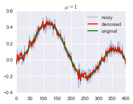

**mu:**

```python
def create_A(n, mu):
    """
    Create the A matrix
    """
    d1=np.eye(n-1,n)
    d1=np.roll(d1,1)
    a_second=  np.sqrt(mu)*(d1+d2)
    a_first=np.eye(n)
    A=np.vstack((a_first,a_second))
    return A

def create_b(n):
    b_2=np.zeros((n-1,1))
    b=np.vstack((corr,b_2))

    return b

def denoise(mu):
    """
    Return denoised signal
    """
    n =  len(corr)
    A = create_A(n, mu)
    b = create_b(n)
    return LA.lstsq(A,b)[0]

def comparison_plot(mu):
    fig, ax = plt.subplots(figsize=(4,3))
    ax.plot(corr,label='noisy',alpha=0.4)
    ax.plot(denoise(np.power(10,mu)),'r',linewidth=2, label='denoised')
    ax.plot(ex,'g',linewidth=2, label='original')
    plt.title(r"$\mu=%d$" % np.power(10,mu))
    plt.legend()
    return fig

from ipywidgets import StaticInteract, RangeWidget
StaticInteract(comparison_plot, mu = RangeWidget(0,5,1))
```

For smaller values of $\mu$, the first constraints is the dominant one and tries to keep the denoised signal close to the noisy one. For higher values of $\mu$, the second constraint dominates.